# Tugas Pertemuan 3

# Uji Asumsi Model

## Uji Autokorelasi (Durbin-Watson)

H0: Tidak ada autokorelasi

```r
# Model Koyck
dwtest(koyck_lm)
```

```
##
##  Durbin-Watson test
##
## data:  koyck_lm
## DW = 0.81175, p-value = 3.675e-09
## alternative hypothesis: true autocorrelation is greater than 0
```

```r
# Model DLM
dwtest(dlm_lm)
```

```
##
##  Durbin-Watson test
##
## data:  dlm_lm
## DW = 0.8844, p-value = 1.7e-05
## alternative hypothesis: true autocorrelation is greater than 0
```

```r
# Model ARDL
dwtest(ardl_lm)
```

```
##
##  Durbin-Watson test
##
## data:  ardl_lm
## DW = 2.0753, p-value = 0.3455
## alternative hypothesis: true autocorrelation is greater than 0
```

## Uji Heteroskedastisitas (Breusch-Pagan)

H0: Ragam sisaan homogen

```r
# Model Koyck
bptest(koyck_lm)
```

```
##
##  studentized Breusch-Pagan test
##
## data:  koyck_lm
## BP = 2.5902, df = 2, p-value = 0.2739
```

```r
# Model DLM
bptest(dlm_lm)
```

```
##
##  studentized Breusch-Pagan test
##
## data:  dlm_lm
## BP = 5.1051, df = 11, p-value = 0.926
```

```r
# Model ARDL
bptest(ardl_lm)
```

```
##
##  studentized Breusch-Pagan test
##
## data:  ardl_lm
## BP = 25.394, df = 22, p-value = 0.2786
```

## Uji Normalitas (Shapiro-Wilk)

H0: Sisaan berdistribusi normal

```r
# Model Koyck
shapiro.test(residuals(koyck_lm))
```

```
##
##  Shapiro-Wilk normality test
##
## data:  residuals(koyck_lm)
## W = 0.98449, p-value = 0.5301
```

```r
# Model DLM
shapiro.test(residuals(dlm_lm))
```

```
##
##  Shapiro-Wilk normality test
##
## data:  residuals(dlm_lm)
## W = 0.97047, p-value = 0.2761
```

```r
# Model ARDL
shapiro.test(residuals(ardl_lm))
```

```
##
##  Shapiro-Wilk normality test
##
## data:  residuals(ardl_lm)
## W = 0.98467, p-value = 0.8358
```

Hasil uji menunjukkan bahwa model ARDL menghasilkan p-value > 0.05 pada uji autokorelasi, heteroskedastisitas, dan normalitas maka tak cukup bukti uuntuk menolak H0 pada ketiga uji tersebut. sedangkan model Koyck dan DLM menghasilkan p-value > 0.05 pada uji heteroskedastisitas dan normalitas dan p-value < 0.05 pada uji autokorelasi maka artinya tak cukup bukti untuk menolak H0 pada uji heteroskedastisitas dan normalitas sedangkan tolak H0 pada uji autokorelasi. Hal ini berarti model ARDL meemnuhi ketiga asumsi tersebuts sedangkan model Koyck dan DLM hanya memenuhi asumsi heteroskedastisitas dn normalitas.

# Perbandingan Performa Model

## Akurasi

```r
# Ringkasan Akurasi MAPE
akurasi <- matrix(c(mape.koyck, mape.dlm.opt, mape.ardl))
row.names(akurasi) <- c("Koyck", "DLM Optimum", "ARDL (15,6)")
colnames(akurasi) <- c("MAPE")
print(akurasi)
```

```
##                  MAPE
## Koyck       0.1848113
## DLM Optimum 0.1136946
## ARDL (15,6) 0.1043768
```

```r
# Ringkasan Akurasi Deviance
akurasidev <- matrix(c(dev.koyck, dev.dlm, dev.ardl))
row.names(akurasidev) <- c("Koyck", "DLM Optimum", "ARDL (15,6)")
colnames(akurasidev) <- c("Deviance")
print(akurasidev)
```

```
##              Deviance
## Koyck       64.742078
## DLM Optimum 17.972757
## ARDL (15,6)  5.988085
```

Nilai MAPE dan deviance terbaik adalah nilai yang terkecil. Hasilnya terlihat bahwa model ARDL memiliki nilai MAPE dan deviance yang terkecil dibandingkan dengan model Koyck dan DLM. Hal ini berarti model ARDL memberikan kinerja peramalan terbaik diantara ketiga metode tersebut.

## Visualisasi

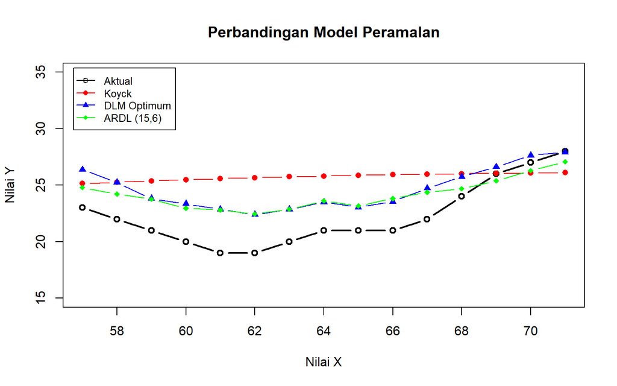

```r
par(mfrow=c(1,1))
plot(test$X, test$AQI, type="b", col="black", ylim=c(15,35), lwd=2,
     ylab="Nilai Y", xlab="Nilai X", main="Perbandingan Model Peramalan")

lines(test$X, fore.koyck$forecasts, col="red", type="b", pch=16)
lines(test$X, fore.dlm.opt$forecasts, col="blue", type="b", pch=17)
lines(test$X, fore.ardl$forecasts, col="green", type="b", pch=18)

legend("topleft", legend=c("Aktual", "Koyck", "DLM Optimum", "ARDL (15,6)"),
       col=c("black","red","blue","green"), lty=1, pch=c(1,16,17,18), cex=0.8, inset=0.02)
```

Grafik diatas menunjukkan bahwa garis hasil peramalan model ARDL (15, 6)/garis hijau dan DLM (10)/garis biru paling mendekati garis nilai aktual/garis hitam. Sedangkan garis hasil model Koyck/gairs merah tidak mendekati garis nilai aktual/garis hitam. Hal tersebut berarti model ARDL (15,6) dan DLM(10) memberikan hasil peramalan yang lebih baik dibandingkan dengan model Koyck.

# Kesimpulan

1. Lag optimum: Lag optimum pada model DLM(q) berada saat q = 10 dan Lag optimum pada model ARDL (p,q) berada saat p = 15 dan q = 6. Sedangkan model Koyck merupakan model yang mengatasi masalah infinite distributed lag, sehingga tidak memerlukan penentuan lag.
2. Hasil uji asumsi menunjukkan hanya model ARDL optimum yang memenuhi semua asumsi (asumsi autokorelasi, normalitas, dan heteroskedastisitas). Sementara model DML dan Koyck tidak memenuhi asumsi autokorelasi.
3. Berdasarkan nilai MAPE, deviance dan visualisasi grafik, model ARDL optimum memberikan kinerja peramalan terbaik diantara ketiga model tersebut. Hal tersebut ditunjukkan dengan model ARDL yang memiliki nilai MAPE dan deviance terkecil dan garis hasil peramalan yang mendekati garis nilai aktual.